# Search and Rescues on the Adirondacks

Kristina Franklin, Rosie Delwiche, Connor Hathaway, Jackie Budka

# Introduction

The observed data is concerning the amount of rescues within New York State. Specifically, the rescues within the Adirondack mountains will be considered. The concerned variables are amount of rangers, amount of people being rescued, age and gender of rescued, and the type of activity that caused the accident. This data is interesting because it can be used to find if certain groups of people should be getting extra safety training before entering the Adirondack Forest.

…

# Background

The data set came from Data World, which got the original data from the New York State Government. The data is an observational study being completed by the search and rescue rangers.

by analyzing this data, we hope to find correlations between the types of rescues performed, and who was being rescued, in the Adirondacks. This will help decide if different people should have more, less, or different safety training before adventuring on their own.

…

# Methods and Results

Summarize data. Use both numerical and graphical summaries.

The two plots below are created from location of the rescues within New York State. Looking at the plot of the entire state, there are two regions where rescues occur more frequently, the high peaks being the larger area of concentration. Because of this concentration, a second plot was made to focus on the rescues within the Adirondack mountains.

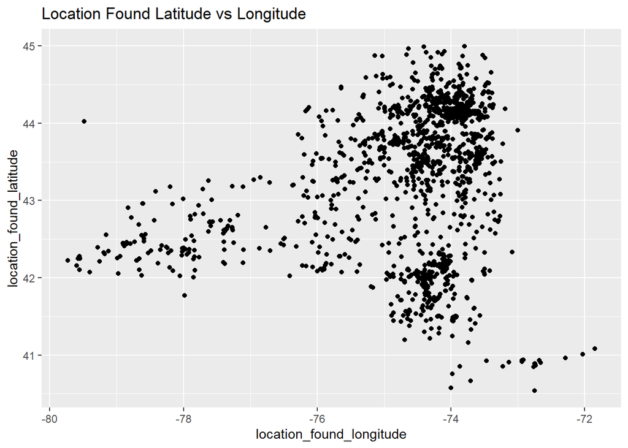

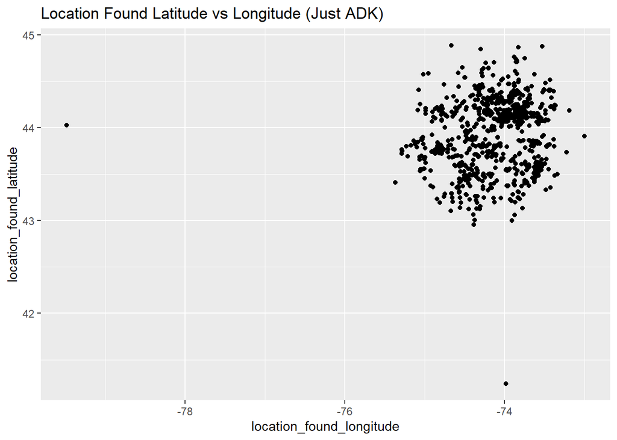

The data has many different variables and presented to us in a large confusing table. The following code sorts the variables we are interested in, and creates a small table for each one.

As you can see, there is more chainsaw then flood victims.

```
##
##         F    M
##    6  827 1245
```

```
##
## Fugitive Search        Recovery          Rescue          Search
##               2              60             902            1114
```

```
##
##             Aircraft               Biking              Boating
##                    8                   12                  133
##              Camping             Chainsaw    Climbing:Rock/Ice
##                   60                    3                   35
##             Criminal           Despondent              Fishing
##                    4                   20                   18
##         Flood Victim               Hiking     Horseback riding
##                    1                 1512                    2
##              Hunting        Motor vehicle Off road vehicle/ATV
##                   74                    6                   16
##              Runaway               Skiing           Snowmobile
##                   17                   23                   63
##             Stranded             Swimming              Walking
##                    3                   26                   40
##           Whitewater
##                    2
```

Check correlation between variables.

```
## Warning: Removed 70 rows containing non-finite values (stat_boxplot).
```

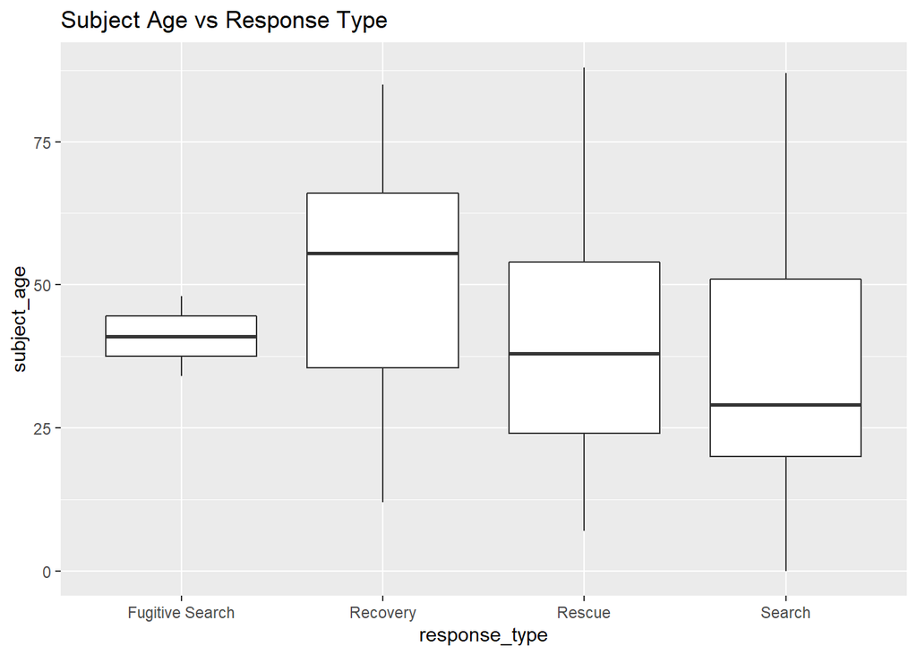

```
## Mean ages
## Recovery=  50.8
```

```
##
## Rescue=  39.83433
```

```
##
## Search=  35.26649
```

Perform at least one relevant hypothesis test.

```
##
##  Welch Two Sample t-test
##
## data:  female$subject_age and male$subject_age
## t = -3.176, df = 1828.6, p-value = 0.001518
## alternative hypothesis: true difference in means is not equal to 0
## 95 percent confidence interval:
##  -4.301948 -1.017200
## sample estimates:
## mean of x mean of y
##  36.05625  38.71582
```

The second hypothesis test performed was a single-tailed hypothesis to see if the ages between rescued males and females differ.  
The null hypothesis is mu_f - mu_m = 0 The alternative hypothesis is mu_f - mu_m < 0 The t-test is performed to find the difference between the two samples. After the t-test is run, the value is -3.176, meaning we reject the null hypothesis because the difference between males and females is not 0.

```
##
##  Welch Two Sample t-test
##
## data:  female$subject_age and male$subject_age
## t = -3.176, df = 1828.6, p-value = 0.0007591
## alternative hypothesis: true difference in means is less than 0
## 95 percent confidence interval:
##       -Inf -1.281465
## sample estimates:
## mean of x mean of y
##  36.05625  38.71582
```

Check the various assumptions of for statistical tests.

```
##
## Call:
## lm(formula = number_of_rangers_involved ~ subject_age, data = raw_adk_data)
##
## Residuals:
##    Min     1Q Median     3Q    Max
## -2.536 -2.207 -1.240  0.590 80.700
##
## Coefficients:
##             Estimate Std. Error t value Pr(>|t|)
## (Intercept) 3.142535   0.219316  14.329   <2e-16 ***
## subject_age 0.004627   0.005212   0.888    0.375
## ---
## Signif. codes:  0 '***' 0.001 '**' 0.01 '*' 0.05 '.' 0.1 ' ' 1
##
## Residual standard error: 4.39 on 2006 degrees of freedom
##   (70 observations deleted due to missingness)
## Multiple R-squared:  0.0003927,  Adjusted R-squared:  -0.0001056
## F-statistic: 0.7882 on 1 and 2006 DF,  p-value: 0.3748
```

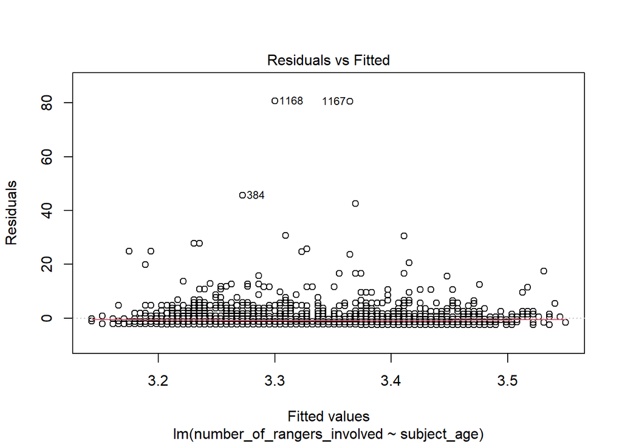

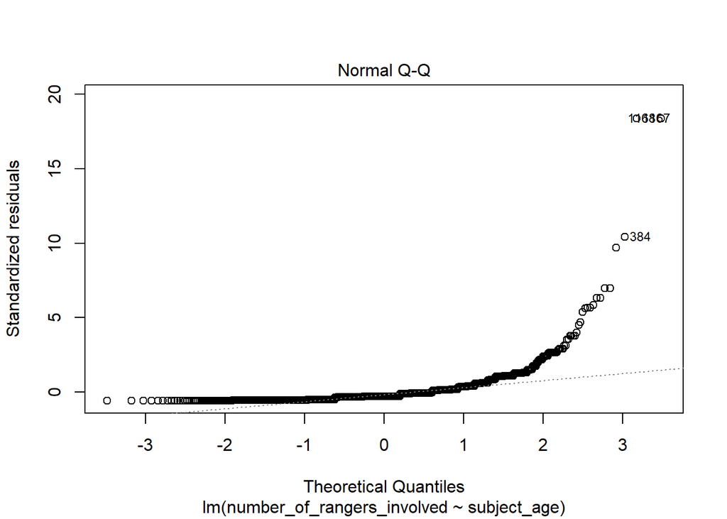

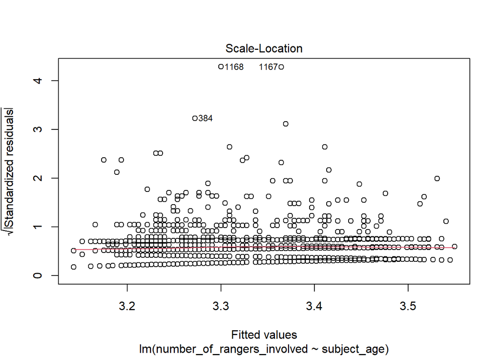

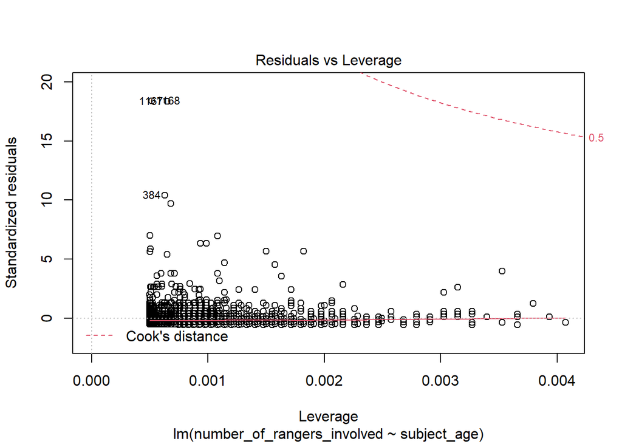

For the linear regression analysis, interpret coefficients and/or make relevant predictions and summarize their meaning.

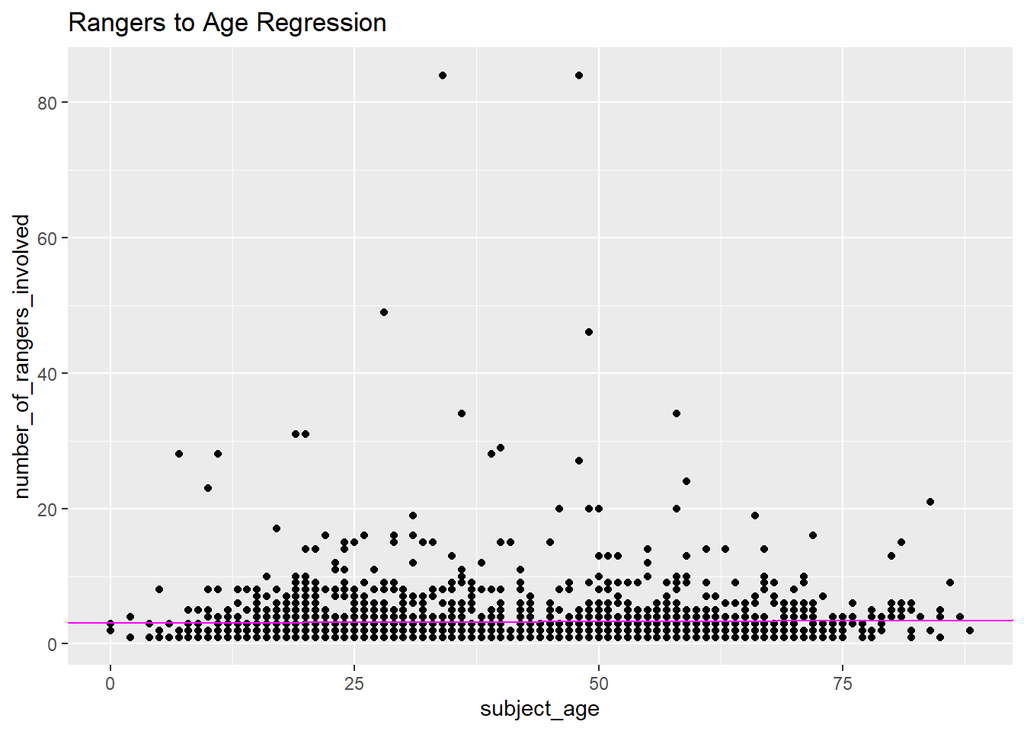

```
## [1] 0.01981789
```

```
##
## Call:
## lm(formula = number_of_rangers_involved ~ subject_age, data = raw_adk_data)
##
## Residuals:
##    Min     1Q Median     3Q    Max
## -2.536 -2.207 -1.240  0.590 80.700
##
## Coefficients:
##             Estimate Std. Error t value Pr(>|t|)
## (Intercept) 3.142535   0.219316  14.329   <2e-16 ***
## subject_age 0.004627   0.005212   0.888    0.375
## ---
## Signif. codes:  0 '***' 0.001 '**' 0.01 '*' 0.05 '.' 0.1 ' ' 1
##
## Residual standard error: 4.39 on 2006 degrees of freedom
##   (70 observations deleted due to missingness)
## Multiple R-squared:  0.0003927,  Adjusted R-squared:  -0.0001056
## F-statistic: 0.7882 on 1 and 2006 DF,  p-value: 0.3748
```

…

# Conclusions

…

# References

Data.world https://data.world/data-ny-gov/u6hu-h7p5